# Movie Likes and Friends

## Background

What could be an easy way to have more friends? Activities through college, work, dating and other events are great options, though, they may take time. An easier way is joining a networking system where there are approximately more than 1.86 billion active users as of 2016. [Facebook User Statistics](http://money.cnn.com/2017/02/01/technology/facebook-earnings/)

This broad networking system called facebook connects people all across the world. Joining facebook gives access to finding friends, but what could a user do to have more friends?

### Question

Is there a relationship between the amount of movies liked and the number of friends a user has on facebook?

## Procedure

In the Facebook Friend Study, a simple random sample of 30 out of 643 friends was taken from a college student’s facebook friend list to use for the data collected on June 1st, 2017. On the facebook friend list, every box beside the person was listed as a default friend, “Friends”, not any other options, such as “Acquaintances” or “Close Friends”. To obtain a simple random sample the tab, “All Friends”, was selected where the friends were in no apparent order.

On the friend list there were two columns. Every 20th friend was chosen in both the first and second column. The number of friends each user had was recorded as well as the number of movies they had “liked”.

## Analysis

Since a simple linear regression test will be conducted to see if there is a relationship between the amount of friends a user has versus the amount of movie liked, a linear regression of the slope, $\beta_1$. will be used in the hypotheses.

$$H_0: \beta_1 = 0$$

$$H_a: \beta_1 \neq 0$$

The declared significance level is

$$\alpha = 0.05$$

## Graphical Summary

If all the requirements were met, this is what the graph would display.

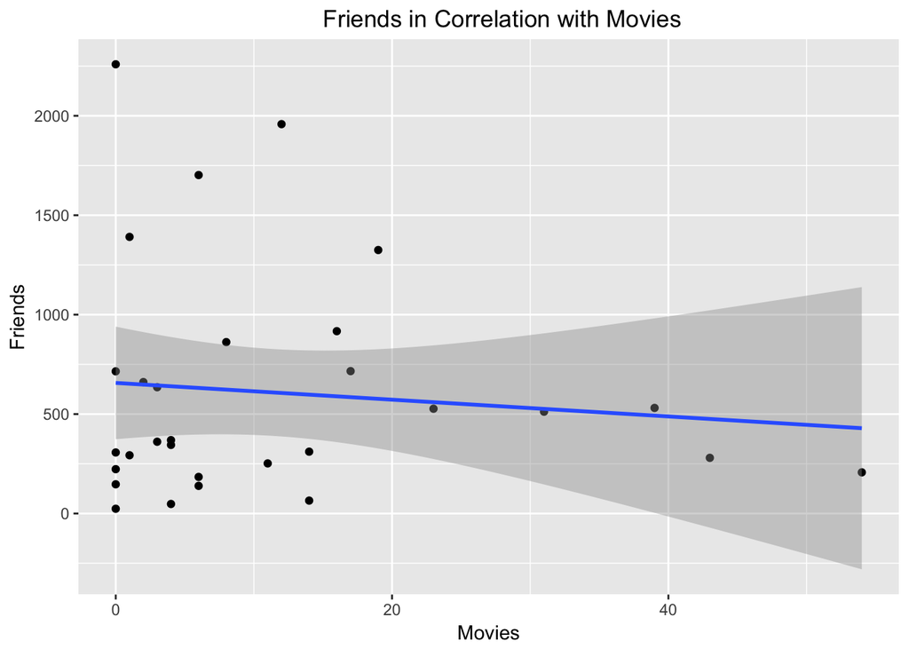

```r
sLine <- lm(Friends ~ Movies, data=StatsLine)


ggplot(data = StatsLine, aes(x=Movies, y=Friends)) + geom_point()   + stat_smooth(method=lm) + theme(legend.position="none") + labs(title="                                     Friends in Correlation with Movies")
```

The equation of the line in the graph above is

$$\ Y= 656.8 - 4.217 X$$
Where the slope is -4.217 and the y-intercept is 656.8.

```r
sLine <- lm(Friends ~ Movies, data=StatsLine)

pander(summary(sLine))
```

|  | Estimate | Std. Error | t value | Pr(>\|t\|) |
| --- | --- | --- | --- | --- |
| **Movies** | -4.217 | 7.731 | -0.5455 | 0.5898 |
| **(Intercept)** | 656.8 | 138.2 | 4.754 | 5.438e-05 |

Fitting linear model: Friends ~ Movies

| Observations | Residual Std. Error | $R^2$ | Adjusted $R^2$ |
| --- | --- | --- | --- |
| 30 | 584 | 0.01051 | -0.02482 |

## Conclusion

To enhance this topic, further studies could be performed to see if there is no coorelation or a negative coorelation with a larger dataset and multiple user’s friend lists.

### Appendix

If the last 5 data points were assumed to be outliers, and thus taken out of the analysis, there might be a slope close to zero. Unfortunately, manipulating the data increases the error of the results of the test. Regardless, a larger sample size and more samples taken from several users would be most helpful in determining if there really is a relationship between the amount of movies liked and the amount of friends a user has.

When transforming the plot, using log scales for both x and y, there shows that there is not a coorelation because the slope is zero.

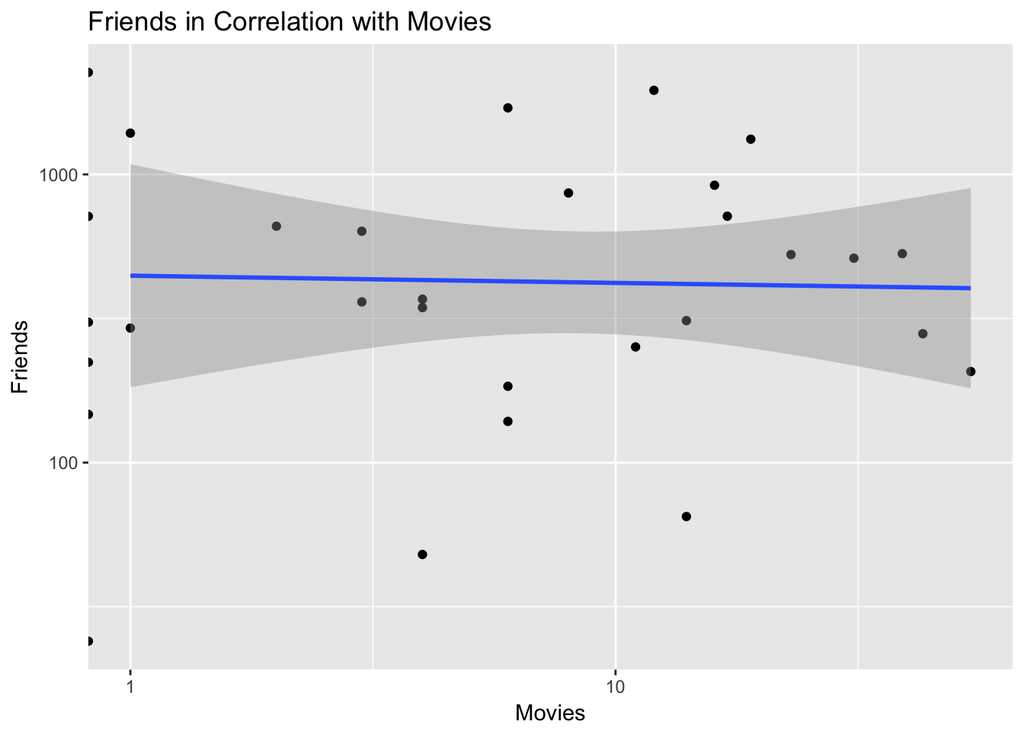

```r
ggplot(data = StatsLine, aes(x=Movies, y=Friends)) + geom_point()  + scale_x_log10() + scale_y_log10()  + stat_smooth(method=lm) + theme(legend.position="none") + labs(title="Friends in Correlation with Movies")
```